# Final Motor Insurance Fraud

```python
# Data processing, CSV file
import pandas as pd
# Linear algebra
import numpy as np
# Graphs and visualisation
import seaborn as sns
%matplotlib inline
import matplotlib.pyplot as plt
# to suppress the warnings
import warnings
warnings.filterwarnings('ignore')
```

```python
data=pd.read_csv("C:\\Users\\amit amar\\Desktop\\Internship\\New one.csv")
```

```python
data.head()
```

|  | PolicyNumber_0 | PolicyStatus_0 | Claimstatus_0 | Claimtype_0 | PartsDamaged_0 | PartsReplaced_0 | PoliceComplaintLodgedYN_0 | SurveyArranged_0 | HistoryClaimStatus_0 | GarageName_0 | ... | SurveyorName_ | Causeofloss_0 | Claimtype_0.1 | Descriptionofloss_0 | DriversRelationshipwithInsured_0 | Licensestatus_0 | ClaimsHandler_0 | ClaimApprovedBy_0 | TotalNoofclaimsmadepreviously | PossibleFraud |
| --- | --- | --- | --- | --- | --- | --- | --- | --- | --- | --- | --- | --- | --- | --- | --- | --- | --- | --- | --- | --- | --- |
| 0 | AP85781569 | Cancelled | Closed | Third Party Bodily Injury | Steering wheel | bumper | Yes | Yes | Repudiated | SM Auto Service | ... | NORBERT | Flood | Third Party Bodily Injury | Hit and run | Spouse | Cancelled | Baiju Menon | NaN | 8 | Y |
| 1 | AP85785622 | Active | Inprocess | Own damage | Steering wheel | bumper | Yes | Yes | Repudiated | SM Auto Service | ... | NORBERT | Earthquake | Own damage | Accident | Spouse | Cancelled | Pankaj Chawla | NaN | 7 | Y |
| 2 | AP85796396 | Active | Settled | Third Party Bodily Injury | Steering wheel | bumper | Yes | Yes | NaN | SM Auto Service | ... | NORBERT | Self-Ignition | Third Party Bodily Injury | Run over pedestrian | Father | Active | Baiju Menon | Stacey Heaton | 0 | Y |
| 3 | AP85778014 | Active | Settled | Own damage | seat | seat | No | Yes | Repudiated | Nagappa Motors | ... | ACKERMAN | Accident | Own damage | Accident | Father | Active | Arasu T | Steffey | 8 | N |
| 4 | AP85772277 | Active | Inprocess | Own damage | dashboard | dashboard | No | Yes | Settled | Balaji Motors | ... | TRISNA | Earthquake | Own damage | Accident | Paid driver | Cancelled | Arasu T | NaN | 9 | N |

5 rows × 22 columns

```python
data.columns
```

```
Index(['PolicyNumber_0', 'PolicyStatus_0', 'Claimstatus_0', 'Claimtype_0',
       'PartsDamaged_0', 'PartsReplaced_0', 'PoliceComplaintLodgedYN_0',
       'SurveyArranged_0', 'HistoryClaimStatus_0', 'GarageName_0', 'FIRno_0',
       'Unnamed: 11', 'SurveyorName_', 'Causeofloss_0', 'Claimtype_0.1',
       'Descriptionofloss_0', 'DriversRelationshipwithInsured_0',
       'Licensestatus_0', 'ClaimsHandler_0', 'ClaimApprovedBy_0',
       'TotalNoofclaimsmadepreviously', 'PossibleFraud'],
      dtype='object')
```

```python
data.shape
```

```
(200232, 22)
```

```python
data.tail()
```

|  | PolicyNumber_0 | PolicyStatus_0 | Claimstatus_0 | Claimtype_0 | PartsDamaged_0 | PartsReplaced_0 | PoliceComplaintLodgedYN_0 | SurveyArranged_0 | HistoryClaimStatus_0 | GarageName_0 | ... | SurveyorName_ | Causeofloss_0 | Claimtype_0.1 | Descriptionofloss_0 | DriversRelationshipwithInsured_0 | Licensestatus_0 | ClaimsHandler_0 | ClaimApprovedBy_0 | TotalNoofclaimsmadepreviously | PossibleFraud |
| --- | --- | --- | --- | --- | --- | --- | --- | --- | --- | --- | --- | --- | --- | --- | --- | --- | --- | --- | --- | --- | --- |
| 200227 | AP85839744 | Cancelled | Closed | Third Party Property Damage | NaN | NaN | Yes | Yes | Repudiated | Ganesh Auto Services | ... | OCELFA | Accident | Third Party Property Damage | Accident | Spouse | Cancelled | Baiju Menon | NaN | 6 | N |
| 200228 | AP85841418 | Active | Repudiated | Theft | NaN | NaN | No | Yes | Repudiated | VMR Motor Services | ... | TATANKA-PTECILA | Theft | Theft | Theft | Father | Expired | RKT Krishnan | NaN | 4 | N |
| 200229 | AP85845681 | Active | Settled | Own damage | fuel injector | fuel injector | Yes | Yes | Repudiated | Ganesh Auto Services | ... | ROXBURY | Flood | Own damage | Accident | Paid driver | Active | Arasu T | Wilkins | 8 | N |
| 200230 | AP85862192 | Active | Settled | Third Party Bodily Injury | NaN | NaN | Yes | Yes | Settled | Vigneshwar Motors | ... | WAINWRIGHT | Fire | Third Party Bodily Injury | Hit and run | Father | Active | Arasu T | Stacey Heaton | 9 | N |
| 200231 | AP85870603 | Cancelled | Closed | Third Party Bodily Injury | NaN | NaN | Yes | Yes | Repudiated | Ganesh Auto Services | ... | CHU'A | Flood | Third Party Bodily Injury | Run over pedestrian | Spouse | Expired | Arasu T | NaN | 5 | N |

5 rows × 22 columns

# Checking for the null values

```python
data.isnull().sum()
```

```
PolicyNumber_0                           0
PolicyStatus_0                           0
Claimstatus_0                            0
Claimtype_0                              0
PartsDamaged_0                      106823
PartsReplaced_0                     106823
PoliceComplaintLodgedYN_0                0
SurveyArranged_0                         0
HistoryClaimStatus_0                 18055
GarageName_0                             0
FIRno_0                             100926
Unnamed: 11                         200232
SurveyorName_                            0
Causeofloss_0                            0
Claimtype_0.1                            0
Descriptionofloss_0                      0
DriversRelationshipwithInsured_0         0
Licensestatus_0                          0
ClaimsHandler_0                          0
ClaimApprovedBy_0                   151956
TotalNoofclaimsmadepreviously            0
PossibleFraud                          232
dtype: int64
```

```python
# percentage of missing values in each column
data.isnull().sum() * 100 / len(data)
```

```
PolicyNumber_0                        0.000000
PolicyStatus_0                        0.000000
Claimstatus_0                         0.000000
Claimtype_0                           0.000000
PartsDamaged_0                       53.349614
PartsReplaced_0                      53.349614
PoliceComplaintLodgedYN_0             0.000000
SurveyArranged_0                      0.000000
HistoryClaimStatus_0                  9.017040
GarageName_0                          0.000000
FIRno_0                              50.404531
Unnamed: 11                         100.000000
SurveyorName_                         0.000000
Causeofloss_0                         0.000000
Claimtype_0.1                         0.000000
Descriptionofloss_0                   0.000000
DriversRelationshipwithInsured_0      0.000000
Licensestatus_0                       0.000000
ClaimsHandler_0                       0.000000
ClaimApprovedBy_0                    75.889968
TotalNoofclaimsmadepreviously         0.000000
PossibleFraud                         0.115866
dtype: float64
```

### Droping 'FIRno_0', 'Unnamed: 11','ClaimApprovedBy_0' columns as there are maximum null values

```python
drop_columns = [ 'FIRno_0', 'Unnamed: 11','ClaimApprovedBy_0']
data = data.drop(drop_columns, axis = 1)
data.head()
```

|  | PolicyNumber_0 | PolicyStatus_0 | Claimstatus_0 | Claimtype_0 | PartsDamaged_0 | PartsReplaced_0 | PoliceComplaintLodgedYN_0 | SurveyArranged_0 | HistoryClaimStatus_0 | GarageName_0 | SurveyorName_ | Causeofloss_0 | Claimtype_0.1 | Descriptionofloss_0 | DriversRelationshipwithInsured_0 | Licensestatus_0 | ClaimsHandler_0 | TotalNoofclaimsmadepreviously | PossibleFraud |
| --- | --- | --- | --- | --- | --- | --- | --- | --- | --- | --- | --- | --- | --- | --- | --- | --- | --- | --- | --- |
| 0 | AP85781569 | Cancelled | Closed | Third Party Bodily Injury | Steering wheel | bumper | Yes | Yes | Repudiated | SM Auto Service | NORBERT | Flood | Third Party Bodily Injury | Hit and run | Spouse | Cancelled | Baiju Menon | 8 | Y |
| 1 | AP85785622 | Active | Inprocess | Own damage | Steering wheel | bumper | Yes | Yes | Repudiated | SM Auto Service | NORBERT | Earthquake | Own damage | Accident | Spouse | Cancelled | Pankaj Chawla | 7 | Y |
| 2 | AP85796396 | Active | Settled | Third Party Bodily Injury | Steering wheel | bumper | Yes | Yes | NaN | SM Auto Service | NORBERT | Self-Ignition | Third Party Bodily Injury | Run over pedestrian | Father | Active | Baiju Menon | 0 | Y |
| 3 | AP85778014 | Active | Settled | Own damage | seat | seat | No | Yes | Repudiated | Nagappa Motors | ACKERMAN | Accident | Own damage | Accident | Father | Active | Arasu T | 8 | N |
| 4 | AP85772277 | Active | Inprocess | Own damage | dashboard | dashboard | No | Yes | Settled | Balaji Motors | TRISNA | Earthquake | Own damage | Accident | Paid driver | Cancelled | Arasu T | 9 | N |

```python
data.shape
```

```
(200232, 19)
```

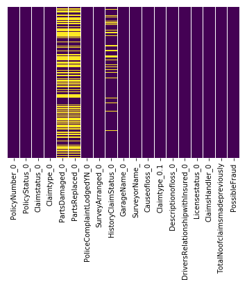

```python
sns.heatmap(data.isnull(),yticklabels=False,cbar=False,cmap='viridis')
```

### Still having null values

```python
data.nunique()
```

```
PolicyNumber_0                      200232
PolicyStatus_0                           2
Claimstatus_0                            5
Claimtype_0                              4
PartsDamaged_0                           8
PartsReplaced_0                          8
PoliceComplaintLodgedYN_0                2
SurveyArranged_0                         1
HistoryClaimStatus_0                     2
GarageName_0                            15
SurveyorName_                          945
Causeofloss_0                            6
Claimtype_0.1                            4
Descriptionofloss_0                      5
DriversRelationshipwithInsured_0         5
Licensestatus_0                          3
ClaimsHandler_0                          5
TotalNoofclaimsmadepreviously           11
PossibleFraud                            2
dtype: int64
```

### Replace the null values with mode

```python
data['PartsDamaged_0'].mode()
data['PartsDamaged_0'].fillna(' Steering wheel',inplace=True)
data['PartsDamaged_0'].isnull().sum()
```

```
0
```

```python
data['PartsReplaced_0' ].mode()
data['PartsReplaced_0'].fillna(' bumper',inplace=True)
data['PartsReplaced_0'].isnull().sum()
```

```
0
```

```python
data['HistoryClaimStatus_0' ].mode()
data['HistoryClaimStatus_0'].fillna(' Repudiated',inplace=True)
data['HistoryClaimStatus_0'].isnull().sum()
```

```
0
```

```python
data['PossibleFraud' ].mode()
data['PossibleFraud'].fillna(' N',inplace=True)
data['PossibleFraud'].isnull().sum()
```

```
0
```

```python
data.isnull().sum() * 100 / len(data)
```

```
PolicyNumber_0                      0.0
PolicyStatus_0                      0.0
Claimstatus_0                       0.0
Claimtype_0                         0.0
PartsDamaged_0                      0.0
PartsReplaced_0                     0.0
PoliceComplaintLodgedYN_0           0.0
SurveyArranged_0                    0.0
HistoryClaimStatus_0                0.0
GarageName_0                        0.0
SurveyorName_                       0.0
Causeofloss_0                       0.0
Claimtype_0.1                       0.0
Descriptionofloss_0                 0.0
DriversRelationshipwithInsured_0    0.0
Licensestatus_0                     0.0
ClaimsHandler_0                     0.0
TotalNoofclaimsmadepreviously       0.0
PossibleFraud                       0.0
dtype: float64
```

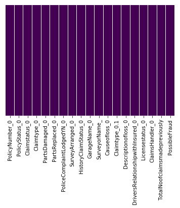

```python
sns.heatmap(data.isnull(),yticklabels=False,cbar=False,cmap='viridis')
```

```python
data['PossibleFraud'].unique()
```

```
array(['Y', 'N', ' N'], dtype=object)
```

```python
data['PossibleFraud']= data['PossibleFraud'].str.replace(' N', 'N', case = False)
```

```python
data['PossibleFraud'].unique()
```

```
array(['Y', 'N'], dtype=object)
```

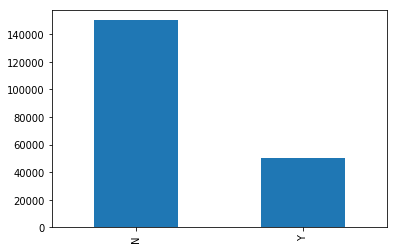

```python
data['PossibleFraud'].value_counts().plot(kind='bar');
```

```python
data['PossibleFraud'].value_counts()
```

```
N    150232
Y     50000
Name: PossibleFraud, dtype: int64
```

### There are 150232 records with no fraud status and 50000 records with fraud status.

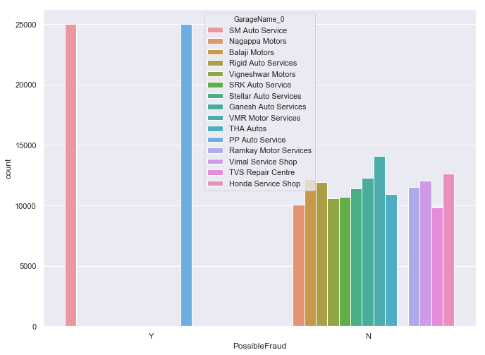

```python
sns.set(rc={'figure.figsize':(11,8.27)})
sns.countplot(x=data['PossibleFraud'],hue=data['GarageName_0'],data=data)
```

### From the above we can say that total 50000 frauds are done in two auto services

### 1. PP Auto service

### 2. SM Auto service

```python
data['PartsReplaced_0'].unique()
```

```
array(['bumper', 'seat', 'dashboard', ' bumper', 'brakes',
       'fuel injector', 'headlight', 'Steering wheel', 'door'],
      dtype=object)
```

```python
data['PartsReplaced_0']= data['PartsReplaced_0'].str.replace(' bumper', 'bumper', case = False)
```

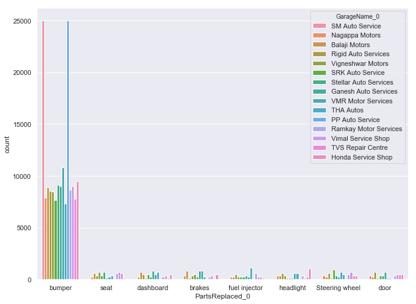

```python
sns.countplot(x=data['PartsReplaced_0'],hue=data['GarageName_0'],data=data)
```

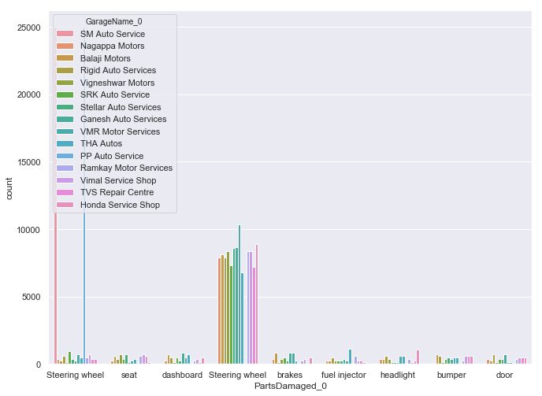

```python
sns.countplot(x=data['PartsDamaged_0'],hue=data['GarageName_0'],data=data)
```

### Both sm auto service and pp auto service they say that steering wheel of the car is damaged and they replace with bumper which is a fraud statement

```python
df=data[data['PossibleFraud']=='Y']
df.head()
```

|  | PolicyNumber_0 | PolicyStatus_0 | Claimstatus_0 | Claimtype_0 | PartsDamaged_0 | PartsReplaced_0 | PoliceComplaintLodgedYN_0 | SurveyArranged_0 | HistoryClaimStatus_0 | GarageName_0 | SurveyorName_ | Causeofloss_0 | Claimtype_0.1 | Descriptionofloss_0 | DriversRelationshipwithInsured_0 | Licensestatus_0 | ClaimsHandler_0 | TotalNoofclaimsmadepreviously | PossibleFraud |
| --- | --- | --- | --- | --- | --- | --- | --- | --- | --- | --- | --- | --- | --- | --- | --- | --- | --- | --- | --- |
| 0 | AP85781569 | Cancelled | Closed | Third Party Bodily Injury | Steering wheel | bumper | Yes | Yes | Repudiated | SM Auto Service | NORBERT | Flood | Third Party Bodily Injury | Hit and run | Spouse | Cancelled | Baiju Menon | 8 | Y |
| 1 | AP85785622 | Active | Inprocess | Own damage | Steering wheel | bumper | Yes | Yes | Repudiated | SM Auto Service | NORBERT | Earthquake | Own damage | Accident | Spouse | Cancelled | Pankaj Chawla | 7 | Y |
| 2 | AP85796396 | Active | Settled | Third Party Bodily Injury | Steering wheel | bumper | Yes | Yes | Repudiated | SM Auto Service | NORBERT | Self-Ignition | Third Party Bodily Injury | Run over pedestrian | Father | Active | Baiju Menon | 0 | Y |
| 11 | AP85787413 | Active | Settled | Own damage | Steering wheel | bumper | Yes | Yes | Repudiated | SM Auto Service | NORBERT | Flood | Own damage | Accident | Spouse | Active | Sudipto Banerjee | 2 | Y |
| 19 | AP85780935 | Active | Inprocess | Theft | Steering wheel | bumper | No | Yes | Settled | PP Auto Service | PEARSON | Theft | Theft | Theft | Mother | Expired | RKT Krishnan | 9 | Y |

```python
df['SurveyorName_'].value_counts(normalize = True)
```

```
NORBERT    0.50004
PEARSON    0.49996
Name: SurveyorName_, dtype: float64
```

### From PP auto service Peorsan is the Surveyors who do false claim the report and present it into the insurer

### From sm auto service Nobert is the Surveyors who do false claim the report and present it into the insurer

```python
df['Causeofloss_0'].value_counts(normalize = True)
```

```
Theft            0.29794
Fire             0.22416
Self-Ignition    0.12778
Earthquake       0.12052
Flood            0.11888
Accident         0.11072
Name: Causeofloss_0, dtype: float64
```

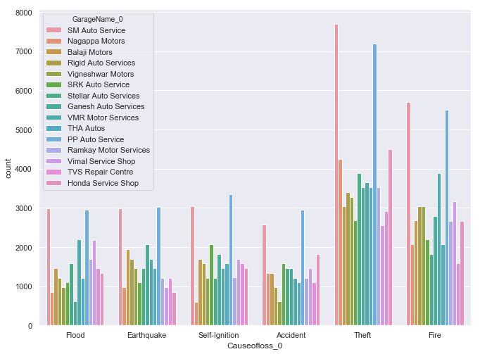

```python
sns.countplot(x=data['Causeofloss_0'],hue=data['GarageName_0'],data=data)
```

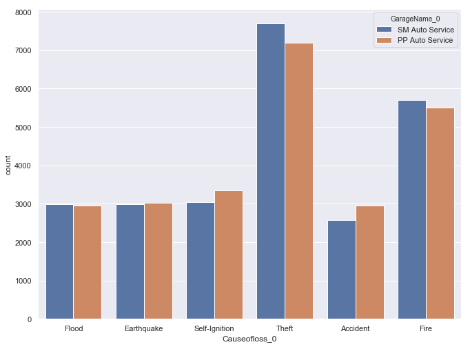

```python
sns.countplot(x=df['Causeofloss_0'],hue=df['GarageName_0'],data=df)
```

### And the loss they described was Theft ,Fire,Self-Ignition,Earthquake,Flood,All this are actually false claims.

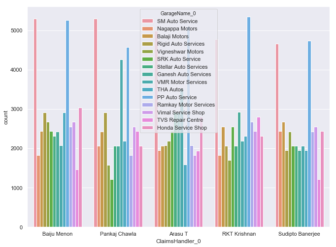

```python
sns.countplot(x=data['ClaimsHandler_0' ],hue=data['GarageName_0'],data=data)
```

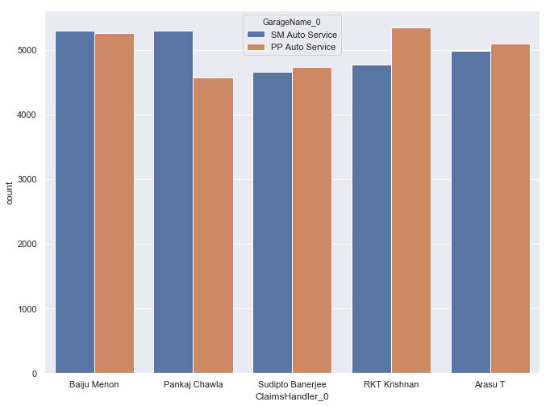

```python
sns.countplot(x=df['ClaimsHandler_0' ],hue=df['GarageName_0'],data=df)
```

### Then it comes to the Claims handlers. Claims handlers are responsible for processing and investigating insurance claims relating to customers' policies.

### For both the auto services there are actually 5 people who are the claim handlers

### Krishnan, Baiju Menon, Arasu , Banerjee and Pankaj Chawla

```python
from sklearn.preprocessing import LabelEncoder

cat_cols = ['PolicyNumber_0', 'PolicyStatus_0', 'Claimstatus_0', 'Claimtype_0',
       'PartsDamaged_0', 'PartsReplaced_0', 'PoliceComplaintLodgedYN_0',
       'SurveyArranged_0', 'HistoryClaimStatus_0', 'GarageName_0',
       'SurveyorName_', 'Causeofloss_0', 'Claimtype_0.1',
       'Descriptionofloss_0', 'DriversRelationshipwithInsured_0',
       'Licensestatus_0', 'ClaimsHandler_0',
       'PossibleFraud']

le = LabelEncoder()

for i in cat_cols:
    data[i] = le.fit_transform(data[i])

data.dtypes
```

```
PolicyNumber_0                      int32
PolicyStatus_0                      int32
Claimstatus_0                       int32
Claimtype_0                         int32
PartsDamaged_0                      int32
PartsReplaced_0                     int32
PoliceComplaintLodgedYN_0           int32
SurveyArranged_0                    int32
HistoryClaimStatus_0                int32
GarageName_0                        int32
SurveyorName_                       int32
Causeofloss_0                       int32
Claimtype_0.1                       int32
Descriptionofloss_0                 int32
DriversRelationshipwithInsured_0    int32
Licensestatus_0                     int32
ClaimsHandler_0                     int32
TotalNoofclaimsmadepreviously       int64
PossibleFraud                       int32
dtype: object
```

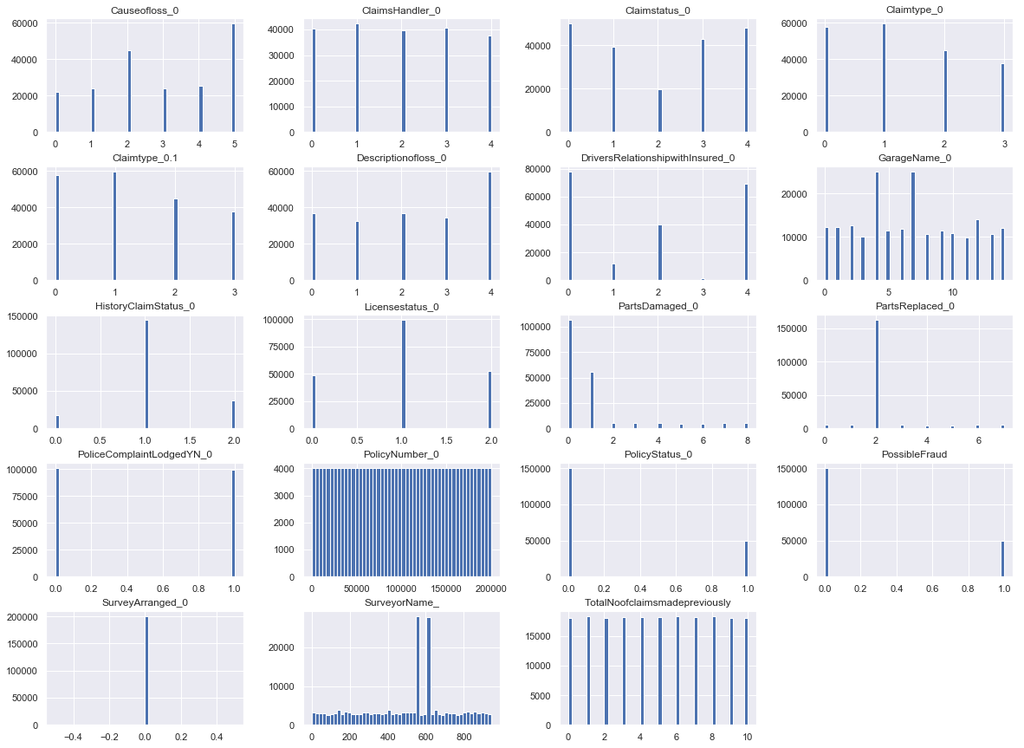

```python
data.hist(bins=50,figsize=(20,15))
plt.show()
```

```python
#Visualing the correlation between attributes
corr_mat = data.corr()
corr_mat['PossibleFraud'].sort_values(ascending = True)
```

```
PolicyNumber_0                     -0.550048
GarageName_0                       -0.175639
PartsReplaced_0                    -0.143149
PartsDamaged_0                     -0.058142
Licensestatus_0                    -0.003630
HistoryClaimStatus_0               -0.002129
TotalNoofclaimsmadepreviously      -0.000943
DriversRelationshipwithInsured_0    0.000066
PoliceComplaintLodgedYN_0           0.000145
Causeofloss_0                       0.000244
ClaimsHandler_0                     0.000258
Claimtype_0                         0.000290
Claimtype_0.1                       0.000290
Descriptionofloss_0                 0.000394
Claimstatus_0                       0.000700
PolicyStatus_0                      0.002984
SurveyorName_                       0.201907
PossibleFraud                       1.000000
SurveyArranged_0                         NaN
Name: PossibleFraud, dtype: float64
```

```python
data.corr()
```

|  | PolicyNumber_0 | PolicyStatus_0 | Claimstatus_0 | Claimtype_0 | PartsDamaged_0 | PartsReplaced_0 | PoliceComplaintLodgedYN_0 | SurveyArranged_0 | HistoryClaimStatus_0 | GarageName_0 | SurveyorName_ | Causeofloss_0 | Claimtype_0.1 | Descriptionofloss_0 | DriversRelationshipwithInsured_0 | Licensestatus_0 | ClaimsHandler_0 | TotalNoofclaimsmadepreviously | PossibleFraud |
| --- | --- | --- | --- | --- | --- | --- | --- | --- | --- | --- | --- | --- | --- | --- | --- | --- | --- | --- | --- |
| PolicyNumber_0 | 1.000000 | -0.004033 | 0.001748 | -0.000242 | 0.032064 | 0.078891 | -0.000091 | NaN | -0.000215 | 0.096303 | -0.111181 | -0.000175 | -0.000242 | -0.000099 | 0.000053 | 0.000760 | 0.000055 | -0.000660 | -0.550048 |
| PolicyStatus_0 | -0.004033 | 1.000000 | -0.749029 | 0.058689 | -0.048045 | -0.031348 | 0.014014 | NaN | 0.002532 | 0.013024 | -0.002192 | 0.033346 | 0.058689 | 0.051555 | 0.005954 | 0.256060 | 0.022971 | 0.001644 | 0.002984 |
| Claimstatus_0 | 0.001748 | -0.749029 | 1.000000 | -0.041077 | 0.041335 | 0.047243 | -0.015231 | NaN | 0.003533 | -0.013798 | -0.000403 | -0.014531 | -0.041077 | -0.002037 | 0.023078 | -0.585964 | 0.006722 | -0.001306 | 0.000700 |
| Claimtype_0 | -0.000242 | 0.058689 | -0.041077 | 1.000000 | -0.566421 | -0.301195 | -0.012603 | NaN | 0.032554 | 0.037220 | 0.003572 | -0.114083 | 1.000000 | 0.211939 | -0.046071 | 0.006872 | -0.033493 | 0.005238 | 0.000290 |
| PartsDamaged_0 | 0.032064 | -0.048045 | 0.041335 | -0.566421 | 1.000000 | 0.856633 | 0.023952 | NaN | -0.042184 | 0.003988 | -0.016974 | -0.253372 | -0.566421 | -0.524275 | 0.034147 | -0.017065 | -0.016601 | -0.004775 | -0.058142 |
| PartsReplaced_0 | 0.078891 | -0.031348 | 0.047243 | -0.301195 | 0.856633 | 1.000000 | 0.001498 | NaN | -0.024892 | 0.032188 | -0.042355 | -0.123139 | -0.301195 | -0.277550 | 0.010485 | -0.038906 | -0.023376 | -0.003623 | -0.143149 |
| PoliceComplaintLodgedYN_0 | -0.000091 | 0.014014 | -0.015231 | -0.012603 | 0.023952 | 0.001498 | 1.000000 | NaN | 0.015011 | 0.000120 | -0.015208 | -0.010594 | -0.012603 | -0.041185 | 0.030281 | 0.008230 | 0.034965 | 0.000252 | 0.000145 |
| SurveyArranged_0 | NaN | NaN | NaN | NaN | NaN | NaN | NaN | NaN | NaN | NaN | NaN | NaN | NaN | NaN | NaN | NaN | NaN | NaN | NaN |
| HistoryClaimStatus_0 | -0.000215 | 0.002532 | 0.003533 | 0.032554 | -0.042184 | -0.024892 | 0.015011 | NaN | 1.000000 | -0.001246 | 0.002415 | 0.038417 | 0.032554 | 0.046975 | 0.017444 | -0.010782 | 0.030438 | 0.331497 | -0.002129 |
| GarageName_0 | 0.096303 | 0.013024 | -0.013798 | 0.037220 | 0.003988 | 0.032188 | 0.000120 | NaN | -0.001246 | 1.000000 | -0.107041 | 0.002049 | 0.037220 | -0.012966 | 0.027048 | -0.016520 | -0.009220 | 0.001399 | -0.175639 |
| SurveyorName_ | -0.111181 | -0.002192 | -0.000403 | 0.003572 | -0.016974 | -0.042355 | -0.015208 | NaN | 0.002415 | -0.107041 | 1.000000 | -0.024373 | 0.003572 | -0.012033 | -0.038379 | -0.020374 | 0.001367 | -0.000250 | 0.201907 |
| Causeofloss_0 | -0.000175 | 0.033346 | -0.014531 | -0.114083 | -0.253372 | -0.123139 | -0.010594 | NaN | 0.038417 | 0.002049 | -0.024373 | 1.000000 | -0.114083 | 0.631239 | 0.000823 | 0.007227 | 0.047355 | -0.000487 | 0.000244 |
| Claimtype_0.1 | -0.000242 | 0.058689 | -0.041077 | 1.000000 | -0.566421 | -0.301195 | -0.012603 | NaN | 0.032554 | 0.037220 | 0.003572 | -0.114083 | 1.000000 | 0.211939 | -0.046071 | 0.006872 | -0.033493 | 0.005238 | 0.000290 |
| Descriptionofloss_0 | -0.000099 | 0.051555 | -0.002037 | 0.211939 | -0.524275 | -0.277550 | -0.041185 | NaN | 0.046975 | -0.012966 | -0.012033 | 0.631239 | 0.211939 | 1.000000 | -0.032146 | -0.029447 | 0.042931 | 0.002832 | 0.000394 |
| DriversRelationshipwithInsured_0 | 0.000053 | 0.005954 | 0.023078 | -0.046071 | 0.034147 | 0.010485 | 0.030281 | NaN | 0.017444 | 0.027048 | -0.038379 | 0.000823 | -0.046071 | -0.032146 | 1.000000 | -0.043072 | 0.003229 | -0.002402 | 0.000066 |
| Licensestatus_0 | 0.000760 | 0.256060 | -0.585964 | 0.006872 | -0.017065 | -0.038906 | 0.008230 | NaN | -0.010782 | -0.016520 | -0.020374 | 0.007227 | 0.006872 | -0.029447 | -0.043072 | 1.000000 | 0.018675 | 0.002196 | -0.003630 |
| ClaimsHandler_0 | 0.000055 | 0.022971 | 0.006722 | -0.033493 | -0.016601 | -0.023376 | 0.034965 | NaN | 0.030438 | -0.009220 | 0.001367 | 0.047355 | -0.033493 | 0.042931 | 0.003229 | 0.018675 | 1.000000 | -0.002560 | 0.000258 |
| TotalNoofclaimsmadepreviously | -0.000660 | 0.001644 | -0.001306 | 0.005238 | -0.004775 | -0.003623 | 0.000252 | NaN | 0.331497 | 0.001399 | -0.000250 | -0.000487 | 0.005238 | 0.002832 | -0.002402 | 0.002196 | -0.002560 | 1.000000 | -0.000943 |
| PossibleFraud | -0.550048 | 0.002984 | 0.000700 | 0.000290 | -0.058142 | -0.143149 | 0.000145 | NaN | -0.002129 | -0.175639 | 0.201907 | 0.000244 | 0.000290 | 0.000394 | 0.000066 | -0.003630 | 0.000258 | -0.000943 | 1.000000 |

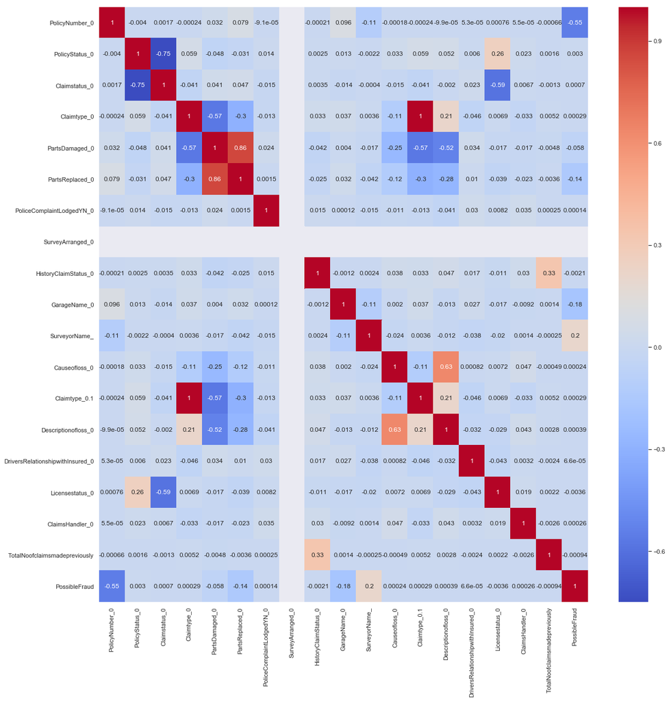

```python
plt.figure(figsize=(20, 20))
sns.heatmap(data.corr(),annot=True,cmap='coolwarm')
```

## Model Evaluation

```python
y=data['PossibleFraud']
x=data.drop(['PossibleFraud'],axis=1)
```

```python
from sklearn.model_selection import train_test_split
x_train,x_test,y_train,y_test=train_test_split(x,y,random_state=0,test_size=0.2)
```

#### Logistic Regression

```python
from sklearn.linear_model import LogisticRegression
from sklearn.metrics import accuracy_score
from sklearn.preprocessing import StandardScaler
lr=LogisticRegression(max_iter=10000)
lr.fit(x_train,y_train)
pred_1=lr.predict(x_test)
score_1=accuracy_score(y_test,pred_1)
```

```python
score_1
```

```
0.8295752490823283
```

#### Random Forest

```python
from sklearn.ensemble import RandomForestClassifier
rfc=RandomForestClassifier()
rfc.fit(x_train,y_train)
pred_2=rfc.predict(x_test)
score_2=accuracy_score(y_test,pred_2)
```

```python
score_2
```

```
1.0
```

#### Gradient boosting Classifer

```python
from sklearn.ensemble import GradientBoostingClassifier
gbc=GradientBoostingClassifier()
gbc.fit(x_train,y_train)
pred_3=gbc.predict(x_test)
score_3=accuracy_score(y_test,pred_3)
```

```python
score_3
```

```
0.9999500586810498
```

#### XGBoost classifier

```python
from xgboost import XGBClassifier
xgb= XGBClassifier()
xgb.fit(x_train,y_train)
pred_4=xgb.predict(x_test)
score_4=accuracy_score(y_test,pred_4)
```

```python
score_4
```

```
0.9999500586810498
```

### Confusion Matrix , Classification Report

```
array([[30141,     1],
       [    1,  9904]], dtype=int64)
```

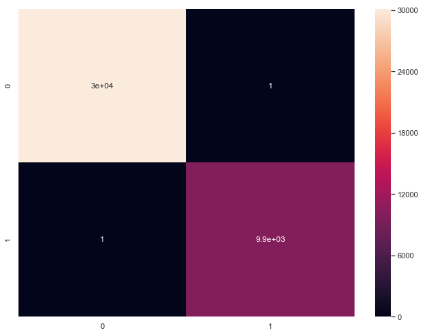

```python
from sklearn.metrics import confusion_matrix,classification_report

cm=confusion_matrix(pred_4,y_test)
sns.heatmap(cm,annot=True)
cm
```

##### The confusion matrix shows 30141+9904 = 40045 correct predictions .

```python
clf=classification_report(pred_4,y_test)
print(clf)
```

```
              precision    recall  f1-score   support

           0       1.00      1.00      1.00     30142
           1       1.00      1.00      1.00      9905

   micro avg       1.00      1.00      1.00     40047
   macro avg       1.00      1.00      1.00     40047
weighted avg       1.00      1.00      1.00     40047
```

#### Isolation and local outlier factor

```python
Fraud = data[data['PossibleFraud']==1]
Valid = data[data['PossibleFraud']==0]
outlier_fraction = len(Fraud)/float(len(Valid))
print(outlier_fraction)
print("Fraud Cases : {}".format(len(Fraud)))
print("Valid Cases : {}".format(len(Valid)))
```

```
0.3328185739389744
Fraud Cases : 50000
Valid Cases : 150232
```

```python
#Create independent and Dependent Features
columns = data.columns.tolist()
# Filter the columns to remove data we do not want
columns = [c for c in columns if c not in ['PossibleFraud']]
# Store the variable we are predicting
target = 'PossibleFraud'
# Define a random state
state = np.random.RandomState(42)
X = data[columns]
Y = data[target]
X_outliers = state.uniform(low=0, high=1, size=(X.shape[0], X.shape[1]))
# Print the shapes of X & Y
print(X.shape)
print(Y.shape)
```

```
(200232, 18)
(200232,)
```

```python
from sklearn.metrics import classification_report,accuracy_score
from sklearn.ensemble import IsolationForest
from sklearn.neighbors import LocalOutlierFactor
from sklearn.svm import OneClassSVM
from pylab import rcParams
rcParams['figure.figsize'] = 14, 8
RANDOM_SEED = 42
LABELS = ["Normal", "Fraud"]
```

```python
##Define the outlier detection methods

classifiers = {
    "Isolation Forest":IsolationForest(n_estimators=100, max_samples=len(X),
                                       contamination=outlier_fraction,random_state=state, verbose=0),
    "Local Outlier Factor":LocalOutlierFactor(n_neighbors=20, algorithm='auto',
                                              leaf_size=30, metric='minkowski',
                                              p=2, metric_params=None, contamination=outlier_fraction),
    "Support Vector Machine":OneClassSVM(kernel='rbf', degree=3, gamma=0.1,nu=0.05,
                                         max_iter=-1, random_state=state)

}
```

```python
type(classifiers)
```

```
dict
```

```python
n_outliers = len(Fraud)
for i, (clf_name,clf) in enumerate(classifiers.items()):
    #Fit the data and tag outliers
    if clf_name == "Local Outlier Factor":
        y_pred = clf.fit_predict(X)
        scores_prediction = clf.negative_outlier_factor_
    elif clf_name == "Support Vector Machine":
        clf.fit(X)
        y_pred = clf.predict(X)
    else:
        clf.fit(X)
        scores_prediction = clf.decision_function(X)
        y_pred = clf.predict(X)
    #Reshape the prediction values to 0 for Valid transactions , 1 for Fraud transactions
    y_pred[y_pred == 1] = 0
    y_pred[y_pred == -1] = 1
    n_errors = (y_pred != Y).sum()
    # Run Classification Metrics
    print("{}: {}".format(clf_name,n_errors))
    print("Accuracy Score :")
    print(accuracy_score(Y,y_pred))
    print("Classification Report :")
    print(classification_report(Y,y_pred))
```

[output not shown]

```
Isolation Forest: 93207
Accuracy Score :
0.5345049742298933
Classification Report :
              precision    recall  f1-score   support

           0       0.71      0.63      0.67    150232
           1       0.18      0.23      0.20     50000

   micro avg       0.53      0.53      0.53    200232
   macro avg       0.44      0.43      0.44    200232
weighted avg       0.58      0.53      0.55    200232

Local Outlier Factor: 85437
Accuracy Score :
0.5733099604458828
Classification Report :
              precision    recall  f1-score   support

           0       0.74      0.66      0.70    150232
           1       0.23      0.31      0.27     50000

   micro avg       0.57      0.57      0.57    200232
   macro avg       0.49      0.49      0.48    200232
weighted avg       0.62      0.57      0.59    200232
```